# Part 5-How many factors-2

Mingyang Cai

Part 5: Structural equation model (MIMIC SEM) How many factors?  
Keep 0 scores (Not Applicable) in the raw RRP/QRP variables.

# Packages used

The following packages are used.

```r
library(dplyr)    # Data manipulation
library(mice)     # Data imputation
library(magrittr) # Pipes
library(purrr)    # Functional programming
library(ggplot2)  # Plotting device
library(lavaan)   # Latent variable analysis
library(psych)    # Factor analysis
library(polycor)  # Polychoric correlation
library(GPArotation) #Rotation
```

# Read in the data file

I load all workspaces from the `\Workspaces\` directory in the project’s root.

```r
load("../Workspaces/1. Data import and preparation.Rdata")
load("../Workspaces/2. Data inspection.Rdata")
load("../Workspaces/3. Data imputation.Rdata")
load("../Workspaces/5. Preparation Imputed Datasets.Rdata")
```

# Setting the RNG seed

```r
set.seed(123)
```

# Combine two dichotomous misconduct items (`RRfabr` and `RRfals`)

```r
rrp <- c("RDisclFunds", "RCorrectPub", "RAuthorship", "ROpenData", "RKeepRecord",
         "RPreReg", "RDataManage", "ROpenAccess", "RCiteSource", "ROpenCode", "RErrorCheck")
qrp <- c("QAttention", "QSupervision", "QResDesign", "QUnfairRev", "QUnsubstClaims",
         "QCiteSource", "QResNotes", "QConcealDetails", "QNoReSubmit", "QConcealFlaws", "QSelectCites")

d50 <- d50 %>%
  map(select, -all_of(rrp), -all_of(qrp))

d50 <- d50 %>%
  map(~ .x %>%
        mutate_at(vars(!!!syms(paste0(rrp, "_raw"))), list(r = ~ recode(., `0` = 0))) %>%
        rename_at(vars(ends_with(("_raw_r"))), ~ gsub("_raw_r", "", .x)) %>%
        mutate_at(vars(!!!syms(paste0(qrp, "_raw"))), list(q = ~ recode(., `0` = 0))) %>%
        rename_at(vars(ends_with(("_raw_q"))), ~ gsub("_raw_q", "", .x)))

d50 <- d50 %>%
  map(~ .x %>%
        mutate(RRP_ave = rowMeans(cbind(!!!syms(rrp)), na.rm = T)) %>%
        mutate(QRP_ave = rowMeans(cbind(!!!syms(qrp)), na.rm = T)))

d50 <- d50 %>%
  map(~ .x %>%
        mutate(QRP_1 = rowSums(cbind(!!!syms(qrp)) > 4)) %>%
        mutate(QRP_1 = if_else(QRP_1 == 0, 0, 1)))

d50 <- d50 %>%
  map(~.x %>%
        mutate(RR_sum = rowSums(cbind(RRfabr, RRfals))))
```

# Test the model with one factor

```r
Model.1 <- '#latent variable definition
            QRP =~ QAttention + QSupervision + QResDesign + QUnfairRev
                 + QUnsubstClaims + QCiteSource + QResNotes + QConcealDetails
                 + QNoReSubmit + QConcealFlaws + QSelectCites
                 + RDisclFunds + RCorrectPub + RAuthorship + ROpenData
                 + RKeepRecord + RPreReg + RDataManage + ROpenAccess
                 + RCiteSource + ROpenCode + RErrorCheck
                 + RR_sum

            #variance and covariance
            RDisclFunds ~~ RAuthorship
            RCorrectPub ~~ RErrorCheck
            ROpenData ~~ ROpenCode
'
fit.model.1 <- cfa(Model.1, data = complete(d50[[1]]), estimator = "WLSMV")
summary(fit.model.1, fit.measures = TRUE)
```

```
## lavaan 0.6-9 ended normally after 77 iterations
##
##   Estimator                                       DWLS
##   Optimization method                           NLMINB
##   Number of model parameters                        49
##
##   Number of observations                          6813
##
## Model Test User Model:
##                                               Standard      Robust
##   Test Statistic                              7128.448    7801.786
##   Degrees of freedom                               227         227
##   P-value (Chi-square)                           0.000       0.000
##   Scaling correction factor                                  0.920
##   Shift parameter                                           49.474
##        simple second-order correction
##
## Model Test Baseline Model:
##
##   Test statistic                             27334.260   12988.298
##   Degrees of freedom                               253         253
##   P-value                                        0.000       0.000
##   Scaling correction factor                                  2.126
##
## User Model versus Baseline Model:
##
##   Comparative Fit Index (CFI)                    0.745       0.405
##   Tucker-Lewis Index (TLI)                       0.716       0.337
##
##   Robust Comparative Fit Index (CFI)                            NA
##   Robust Tucker-Lewis Index (TLI)                               NA
##
## Root Mean Square Error of Approximation:
##
##   RMSEA                                          0.067       0.070
##   90 Percent confidence interval - lower         0.065       0.069
##   90 Percent confidence interval - upper         0.068       0.071
##   P-value RMSEA <= 0.05                          0.000       0.000
##
##   Robust RMSEA                                                  NA
```

[output cut: 60 more lines]

```
##    .QConcealFlaws     2.891    0.065   44.219    0.000
##    .QSelectCites      2.482    0.051   48.204    0.000
##    .RDisclFunds       4.599    0.108   42.472    0.000
##    .RCorrectPub       9.586    0.088  108.338    0.000
##    .RAuthorship       3.828    0.069   55.745    0.000
##    .ROpenData         4.589    0.073   62.833    0.000
##    .RKeepRecord       4.208    0.056   75.328    0.000
##    .RPreReg           5.556    0.082   67.429    0.000
##    .RDataManage       4.373    0.085   51.724    0.000
##    .ROpenAccess       3.900    0.070   55.865    0.000
##    .RCiteSource       1.783    0.078   22.923    0.000
##    .ROpenCode         4.940    0.079   62.623    0.000
##    .RErrorCheck       2.358    0.067   35.118    0.000
##    .RR_sum            0.315    0.006   55.733    0.000
##     QRP               0.288    0.026   10.891    0.000
```

CFI is 0.75.

# Five modifications to improve Model 1

```r
modificationindices(fit.model.1, sort. = TRUE, maximum.number = 5)
```

```
##                lhs op            rhs      mi   epc sepc.lv sepc.all sepc.nox
## 274    RKeepRecord ~~    RDataManage 301.419 1.271   1.271    0.296    0.296
## 134 QUnsubstClaims ~~      QResNotes 163.558 0.327   0.327    0.194    0.194
## 95      QResDesign ~~ QUnsubstClaims 154.301 0.265   0.265    0.222    0.222
## 296    RCiteSource ~~    RErrorCheck 133.477 0.724   0.724    0.353    0.353
## 138 QUnsubstClaims ~~   QSelectCites 133.386 0.315   0.315    0.187    0.187
```

```r
Model.1.modi <- '#latent variable definition
            QRP =~ QAttention + QSupervision + QResDesign + QUnfairRev
                 + QUnsubstClaims + QCiteSource + QResNotes + QConcealDetails
                 + QNoReSubmit + QConcealFlaws + QSelectCites
                 + RDisclFunds + RCorrectPub + RAuthorship + ROpenData
                 + RKeepRecord + RPreReg + RDataManage + ROpenAccess
                 + RCiteSource + ROpenCode + RErrorCheck
                 + RR_sum

            #variance and covariance
            RDisclFunds ~~ RAuthorship
            RCorrectPub ~~ RErrorCheck
            ROpenData ~~ ROpenCode
            RKeepRecord ~~ RDataManage
            QUnsubstClaims ~~ QResNotes
            QResDesign ~~ QUnsubstClaims
            RCiteSource ~~ RErrorCheck
            QUnsubstClaims ~~ QSelectCites

'
fit.model.1.modi <- cfa(Model.1.modi, data = complete(d50[[1]]), estimator = "WLSMV")
summary(fit.model.1.modi, fit.measures = TRUE)
```

```
## lavaan 0.6-9 ended normally after 81 iterations
##
##   Estimator                                       DWLS
##   Optimization method                           NLMINB
##   Number of model parameters                        54
##
##   Number of observations                          6813
##
## Model Test User Model:
##                                               Standard      Robust
##   Test Statistic                              6208.027    6835.866
##   Degrees of freedom                               222         222
##   P-value (Chi-square)                           0.000       0.000
##   Scaling correction factor                                  0.915
##   Shift parameter                                           47.472
##        simple second-order correction
##
## Model Test Baseline Model:
##
##   Test statistic                             27334.260   12988.298
##   Degrees of freedom                               253         253
##   P-value                                        0.000       0.000
##   Scaling correction factor                                  2.126
##
## User Model versus Baseline Model:
##
##   Comparative Fit Index (CFI)                    0.779       0.481
##   Tucker-Lewis Index (TLI)                       0.748       0.408
##
##   Robust Comparative Fit Index (CFI)                            NA
##   Robust Tucker-Lewis Index (TLI)                               NA
##
## Root Mean Square Error of Approximation:
##
##   RMSEA                                          0.063       0.066
##   90 Percent confidence interval - lower         0.062       0.065
##   90 Percent confidence interval - upper         0.064       0.067
##   P-value RMSEA <= 0.05                          0.000       0.000
##
##   Robust RMSEA                                                  NA
```

[output cut: 70 more lines]

```
##    .QConcealFlaws     2.896    0.065   44.347    0.000
##    .QSelectCites      2.516    0.051   48.935    0.000
##    .RDisclFunds       4.545    0.108   42.055    0.000
##    .RCorrectPub       9.534    0.090  105.660    0.000
##    .RAuthorship       3.806    0.068   55.898    0.000
##    .ROpenData         4.541    0.074   61.695    0.000
##    .RKeepRecord       4.252    0.056   75.913    0.000
##    .RPreReg           5.529    0.083   66.624    0.000
##    .RDataManage       4.420    0.085   51.741    0.000
##    .ROpenAccess       3.848    0.070   55.022    0.000
##    .RCiteSource       1.784    0.078   22.900    0.000
##    .ROpenCode         4.857    0.080   60.580    0.000
##    .RErrorCheck       2.357    0.067   35.125    0.000
##    .RR_sum            0.315    0.006   55.735    0.000
##     QRP               0.278    0.026   10.580    0.000
```

CFI increases to 0.78.

# Test the model with two factors

```r
Model.2 <- '#latent variable definition
            QRP =~ QAttention + QSupervision + QResDesign + QUnfairRev
                 + QUnsubstClaims + QCiteSource + QResNotes + QConcealDetails
                 + QNoReSubmit + QConcealFlaws + QSelectCites
                 + RR_sum
            RRP =~ RDisclFunds + RCorrectPub + RAuthorship + ROpenData
                 + RKeepRecord + RPreReg + RDataManage + ROpenAccess
                 + RCiteSource + ROpenCode + RErrorCheck

            #variance and covariance
            RDisclFunds ~~ RAuthorship
            RCorrectPub ~~ RErrorCheck
            ROpenData ~~ ROpenCode

'
fit.model.2 <- cfa(Model.2, data = complete(d50[[1]]), estimator = "WLSMV", std.lv=TRUE)
summary(fit.model.2, fit.measures = TRUE)
```

```
## lavaan 0.6-9 ended normally after 69 iterations
##
##   Estimator                                       DWLS
##   Optimization method                           NLMINB
##   Number of model parameters                        50
##
##   Number of observations                          6813
##
## Model Test User Model:
##                                               Standard      Robust
##   Test Statistic                              3449.346    3889.863
##   Degrees of freedom                               226         226
##   P-value (Chi-square)                           0.000       0.000
##   Scaling correction factor                                  0.897
##   Shift parameter                                           42.513
##        simple second-order correction
##
## Model Test Baseline Model:
##
##   Test statistic                             27334.260   12988.298
##   Degrees of freedom                               253         253
##   P-value                                        0.000       0.000
##   Scaling correction factor                                  2.126
##
## User Model versus Baseline Model:
##
##   Comparative Fit Index (CFI)                    0.881       0.712
##   Tucker-Lewis Index (TLI)                       0.867       0.678
##
##   Robust Comparative Fit Index (CFI)                            NA
##   Robust Tucker-Lewis Index (TLI)                               NA
##
## Root Mean Square Error of Approximation:
##
##   RMSEA                                          0.046       0.049
##   90 Percent confidence interval - lower         0.044       0.047
##   90 Percent confidence interval - upper         0.047       0.050
##   P-value RMSEA <= 0.05                          1.000       0.930
##
##   Robust RMSEA                                                  NA
```

[output cut: 64 more lines]

```
##    .QSelectCites      2.274    0.053   42.615    0.000
##    .RR_sum            0.314    0.006   55.704    0.000
##    .RDisclFunds       4.075    0.112   36.507    0.000
##    .RCorrectPub       9.377    0.094   99.911    0.000
##    .RAuthorship       3.594    0.067   53.936    0.000
##    .ROpenData         3.922    0.085   46.042    0.000
##    .RKeepRecord       4.005    0.060   66.559    0.000
##    .RPreReg           5.508    0.082   67.419    0.000
##    .RDataManage       3.979    0.088   45.178    0.000
##    .ROpenAccess       3.519    0.074   47.589    0.000
##    .RCiteSource       1.693    0.072   23.654    0.000
##    .ROpenCode         4.371    0.089   49.077    0.000
##    .RErrorCheck       2.154    0.059   36.222    0.000
##     QRP               1.000
##     RRP               1.000
```

The CFI is 0.88.

# Five modifications to improve Model 2

```r
modificationindices(fit.model.2, sort. = TRUE, maximum.number = 5)
```

```
##             lhs op            rhs      mi    epc sepc.lv sepc.all sepc.nox
## 72          RRP =~    QNoReSubmit 288.220  0.353   0.353    0.192    0.192
## 306 RKeepRecord ~~    RDataManage 187.349  1.036   1.036    0.259    0.259
## 68          RRP =~ QUnsubstClaims 177.858 -0.188  -0.188   -0.167   -0.167
## 67          RRP =~     QUnfairRev 174.011  0.113   0.113    0.163    0.163
## 236 QNoReSubmit ~~      ROpenCode 137.120  0.662   0.662    0.194    0.194
```

```r
Model.2.modi <- '#latent variable definition
            QRP =~ QAttention + QSupervision + QResDesign + QUnfairRev
                 + QUnsubstClaims + QCiteSource + QResNotes + QConcealDetails
                 + QNoReSubmit + QConcealFlaws + QSelectCites
                 + RR_sum
            RRP =~ RDisclFunds + RCorrectPub + RAuthorship + ROpenData
                 + RKeepRecord + RPreReg + RDataManage + ROpenAccess
                 + RCiteSource + ROpenCode + RErrorCheck
                 + QNoReSubmit + QUnsubstClaims + QUnfairRev

            #variance and covariance
            RDisclFunds ~~ RAuthorship
            RCorrectPub ~~ RErrorCheck
            ROpenData ~~ ROpenCode
            RKeepRecord ~~ RDataManage
            QNoReSubmit ~~ ROpenCode

'
fit.model.2.modi <- cfa(Model.2.modi, data = complete(d50[[1]]), estimator = "WLSMV", std.lv=TRUE)
summary(fit.model.2.modi, fit.measures = TRUE)
```

```
## lavaan 0.6-9 ended normally after 72 iterations
##
##   Estimator                                       DWLS
##   Optimization method                           NLMINB
##   Number of model parameters                        55
##
##   Number of observations                          6813
##
## Model Test User Model:
##                                               Standard      Robust
##   Test Statistic                              2570.838    2984.486
##   Degrees of freedom                               221         221
##   P-value (Chi-square)                           0.000       0.000
##   Scaling correction factor                                  0.873
##   Shift parameter                                           40.147
##        simple second-order correction
##
## Model Test Baseline Model:
##
##   Test statistic                             27334.260   12988.298
##   Degrees of freedom                               253         253
##   P-value                                        0.000       0.000
##   Scaling correction factor                                  2.126
##
## User Model versus Baseline Model:
##
##   Comparative Fit Index (CFI)                    0.913       0.783
##   Tucker-Lewis Index (TLI)                       0.901       0.752
##
##   Robust Comparative Fit Index (CFI)                            NA
##   Robust Tucker-Lewis Index (TLI)                               NA
##
## Root Mean Square Error of Approximation:
##
##   RMSEA                                          0.040       0.043
##   90 Percent confidence interval - lower         0.038       0.041
##   90 Percent confidence interval - upper         0.041       0.044
##   P-value RMSEA <= 0.05                          1.000       1.000
##
##   Robust RMSEA                                                  NA
```

[output cut: 71 more lines]

```
##    .QSelectCites      2.245    0.054   41.697    0.000
##    .RR_sum            0.314    0.006   55.696    0.000
##    .RDisclFunds       4.063    0.111   36.684    0.000
##    .RCorrectPub       9.320    0.095   97.826    0.000
##    .RAuthorship       3.567    0.066   53.918    0.000
##    .ROpenData         3.908    0.084   46.310    0.000
##    .RKeepRecord       4.108    0.059   69.072    0.000
##    .RPreReg           5.506    0.082   66.869    0.000
##    .RDataManage       4.141    0.089   46.555    0.000
##    .ROpenAccess       3.456    0.074   47.000    0.000
##    .RCiteSource       1.690    0.071   23.663    0.000
##    .ROpenCode         4.408    0.088   50.058    0.000
##    .RErrorCheck       2.149    0.059   36.357    0.000
##     QRP               1.000
##     RRP               1.000
```

The CFI now is 0.91.

# Investigate model with three factors with explanatory factor analysis

```r
efa.fit.3 <- complete(d50[[1]]) %>% extract(c(118 : 140)) %>% hetcor(ML = TRUE) %>% use_series(correlations) %>% fa(., nfactors = 3, rotate = "promax")
print(efa.fit.3)
```

```
## Factor Analysis using method =  minres
## Call: fa(r = ., nfactors = 3, rotate = "promax")
## Standardized loadings (pattern matrix) based upon correlation matrix
##                   MR2   MR1   MR3     h2   u2 com
## RDisclFunds      0.09  0.48  0.07 0.3001 0.70 1.1
## RCorrectPub      0.07  0.22  0.10 0.0961 0.90 1.6
## RAuthorship     -0.09  0.55 -0.06 0.2612 0.74 1.1
## ROpenData       -0.04  0.31  0.34 0.3018 0.70 2.0
## RKeepRecord     -0.09 -0.06  0.56 0.2775 0.72 1.1
## RPreReg          0.13  0.04  0.35 0.1725 0.83 1.3
## RDataManage     -0.01  0.02  0.60 0.3619 0.64 1.0
## ROpenAccess      0.03  0.61 -0.06 0.3501 0.65 1.0
## RCiteSource     -0.13  0.54 -0.03 0.2639 0.74 1.1
## ROpenCode        0.08  0.33  0.27 0.2931 0.71 2.1
## RErrorCheck     -0.14  0.45  0.15 0.2716 0.73 1.4
## QAttention       0.41 -0.04  0.06 0.1747 0.83 1.1
## QSupervision     0.30  0.21 -0.10 0.1430 0.86 2.1
## QResDesign       0.51 -0.17  0.18 0.2937 0.71 1.5
## QUnfairRev       0.30  0.32 -0.16 0.1948 0.81 2.5
## QUnsubstClaims   0.54 -0.09 -0.01 0.2727 0.73 1.1
## QCiteSource      0.44 -0.04 -0.08 0.1829 0.82 1.1
## QResNotes        0.46 -0.05 -0.01 0.2047 0.80 1.0
## QConcealDetails  0.49  0.08 -0.04 0.2527 0.75 1.1
## QNoReSubmit      0.32  0.10  0.12 0.1743 0.83 1.5
## QConcealFlaws    0.37  0.11  0.04 0.1780 0.82 1.2
## QSelectCites     0.45 -0.02 -0.01 0.1923 0.81 1.0
## RR_sum           0.06 -0.04  0.00 0.0037 1.00 1.8
##
##                        MR2  MR1  MR3
## SS loadings           2.08 1.94 1.19
## Proportion Var        0.09 0.08 0.05
## Cumulative Var        0.09 0.18 0.23
## Proportion Explained  0.40 0.37 0.23
## Cumulative Proportion 0.40 0.77 1.00
##
##  With factor correlations of
##      MR2  MR1  MR3
## MR2 1.00 0.25 0.24
## MR1 0.25 1.00 0.48
## MR3 0.24 0.48 1.00
##
## Mean item complexity =  1.4
## Test of the hypothesis that 3 factors are sufficient.
##
## The degrees of freedom for the null model are  253  and the objective function was  2.95
## The degrees of freedom for the model are 187  and the objective function was  0.31
##
## The root mean square of the residuals (RMSR) is  0.03
## The df corrected root mean square of the residuals is  0.03
##
## Fit based upon off diagonal values = 0.96
## Measures of factor score adequacy
##                                                    MR2  MR1  MR3
## Correlation of (regression) scores with factors   0.86 0.86 0.81
## Multiple R square of scores with factors          0.73 0.74 0.65
## Minimum correlation of possible factor scores     0.47 0.48 0.30
```

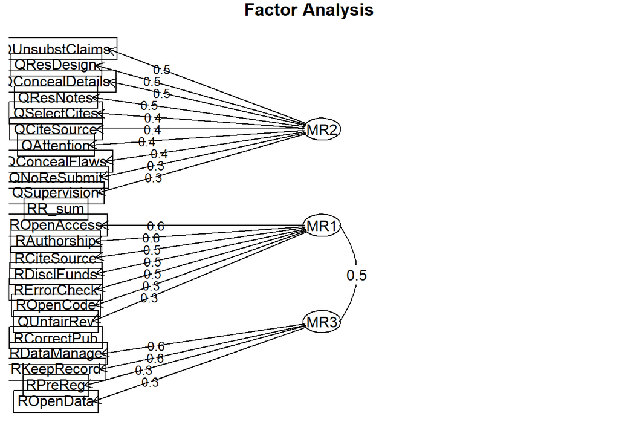

```r
fa.diagram(efa.fit.3)
```

The factor path plot shows the structure of the model with three factors. `MR2` is the QRP factor, `MR1` is one RRP factor (RRP.1) and `MR3` is the other RRP factor (RRP.2). In this plot, the variable `QUnfairRev` is an indicator of RRP.1. However, since the loading of `QUnfairRev` is 0.32 on RRP.1 and is 0.3 on QRP. I still treat `QUnfairRev` as an indicator of QRP. Similarly, because the prior assumption of correlated residuals between open data and open code, I treat `ROpenData` and `ROpenCode` as indicators of RRP.2. In fact, the plot shows that these two variables are indicators of different RRP factors.

# Perform confirmatory factor analysis with three factors

```r
Model.3 <- '#latent variable definition
            QRP =~ QAttention + QSupervision + QResDesign + QUnfairRev
                 + QUnsubstClaims + QCiteSource + QResNotes + QConcealDetails
                 + QNoReSubmit + QConcealFlaws + QSelectCites
                 + RR_sum
            RRP.1 =~ RDisclFunds + RCorrectPub + RAuthorship  + ROpenAccess
                   + RCiteSource  + RErrorCheck
            RRP.2 =~ RKeepRecord + RDataManage + ROpenData + ROpenCode
                   + RPreReg
            #variance and covariance
            RDisclFunds ~~ RAuthorship
            RCorrectPub ~~ RErrorCheck
            ROpenData ~~ ROpenCode
            RRP.1 ~~ RRP.2


'
fit.model.3 <- cfa(Model.3, data = complete(d50[[1]]), estimator = "WLSMV")
summary(fit.model.3, fit.measures = TRUE)
```

```
## lavaan 0.6-9 ended normally after 77 iterations
##
##   Estimator                                       DWLS
##   Optimization method                           NLMINB
##   Number of model parameters                        52
##
##   Number of observations                          6813
##
## Model Test User Model:
##                                               Standard      Robust
##   Test Statistic                              3214.089    3681.009
##   Degrees of freedom                               224         224
##   P-value (Chi-square)                           0.000       0.000
##   Scaling correction factor                                  0.883
##   Shift parameter                                           40.908
##        simple second-order correction
##
## Model Test Baseline Model:
##
##   Test statistic                             27334.260   12988.298
##   Degrees of freedom                               253         253
##   P-value                                        0.000       0.000
##   Scaling correction factor                                  2.126
##
## User Model versus Baseline Model:
##
##   Comparative Fit Index (CFI)                    0.890       0.729
##   Tucker-Lewis Index (TLI)                       0.875       0.693
##
##   Robust Comparative Fit Index (CFI)                            NA
##   Robust Tucker-Lewis Index (TLI)                               NA
##
## Root Mean Square Error of Approximation:
##
##   RMSEA                                          0.044       0.048
##   90 Percent confidence interval - lower         0.043       0.046
##   90 Percent confidence interval - upper         0.046       0.049
##   P-value RMSEA <= 0.05                          1.000       0.998
##
##   Robust RMSEA                                                  NA
```

[output cut: 69 more lines]

```
##    .RR_sum            0.314    0.006   55.704    0.000
##    .RDisclFunds       3.571    0.122   29.201    0.000
##    .RCorrectPub       9.270    0.098   94.413    0.000
##    .RAuthorship       3.416    0.068   49.966    0.000
##    .ROpenAccess       3.187    0.080   39.624    0.000
##    .RCiteSource       1.627    0.067   24.173    0.000
##    .RErrorCheck       2.036    0.057   35.494    0.000
##    .RKeepRecord       3.941    0.062   64.046    0.000
##    .RDataManage       3.843    0.088   43.481    0.000
##    .ROpenData         3.684    0.097   38.030    0.000
##    .ROpenCode         3.978    0.112   35.631    0.000
##    .RPreReg           5.367    0.084   63.738    0.000
##     QRP               0.459    0.034   13.517    0.000
##     RRP.1             2.227    0.131   16.953    0.000
##     RRP.2             0.515    0.051   10.073    0.000
```

The CFI is 0.89.

# Five modifications to improve Model 3

```r
modificationindices(fit.model.3, sort. = TRUE, maximum.number = 5)
```

```
##      lhs op            rhs      mi    epc sepc.lv sepc.all sepc.nox
## 92 RRP.2 =~    QNoReSubmit 307.902  0.527   0.378    0.206    0.206
## 75 RRP.1 =~    QNoReSubmit 233.465  0.211   0.315    0.172    0.172
## 70 RRP.1 =~     QUnfairRev 224.003  0.087   0.130    0.188    0.188
## 71 RRP.1 =~ QUnsubstClaims 172.534 -0.126  -0.188   -0.167   -0.167
## 88 RRP.2 =~ QUnsubstClaims 169.203 -0.262  -0.188   -0.167   -0.167
```

```r
Model.3.modi <- '#latent variable definition
            QRP =~ QAttention + QSupervision + QResDesign + QUnfairRev
                 + QUnsubstClaims + QCiteSource + QResNotes + QConcealDetails
                 + QNoReSubmit + QConcealFlaws + QSelectCites
                 + RR_sum
            RRP.1 =~ RDisclFunds + RCorrectPub + RAuthorship  + ROpenAccess
                   + RCiteSource  + RErrorCheck
                   + QNoReSubmit + QUnfairRev + QUnsubstClaims
            RRP.2 =~ RKeepRecord + RDataManage + ROpenData + ROpenCode
                   + RPreReg
                   + QNoReSubmit + QUnsubstClaims
            #variance and covariance
            RDisclFunds ~~ RAuthorship
            RCorrectPub ~~ RErrorCheck
            ROpenData ~~ ROpenCode
            RRP.1 ~~ RRP.2

'
fit.model.3.modi <- cfa(Model.3.modi, data = complete(d50[[1]]), estimator = "WLSMV")
summary(fit.model.3.modi, fit.measures = TRUE)
```

```
## lavaan 0.6-9 ended normally after 84 iterations
##
##   Estimator                                       DWLS
##   Optimization method                           NLMINB
##   Number of model parameters                        57
##
##   Number of observations                          6813
##
## Model Test User Model:
##                                               Standard      Robust
##   Test Statistic                              2499.201    2955.307
##   Degrees of freedom                               219         219
##   P-value (Chi-square)                           0.000       0.000
##   Scaling correction factor                                  0.857
##   Shift parameter                                           38.400
##        simple second-order correction
##
## Model Test Baseline Model:
##
##   Test statistic                             27334.260   12988.298
##   Degrees of freedom                               253         253
##   P-value                                        0.000       0.000
##   Scaling correction factor                                  2.126
##
## User Model versus Baseline Model:
##
##   Comparative Fit Index (CFI)                    0.916       0.785
##   Tucker-Lewis Index (TLI)                       0.903       0.752
##
##   Robust Comparative Fit Index (CFI)                            NA
##   Robust Tucker-Lewis Index (TLI)                               NA
##
## Root Mean Square Error of Approximation:
##
##   RMSEA                                          0.039       0.043
##   90 Percent confidence interval - lower         0.038       0.041
##   90 Percent confidence interval - upper         0.040       0.044
##   P-value RMSEA <= 0.05                          1.000       1.000
##
##   Robust RMSEA                                                  NA
```

[output cut: 74 more lines]

```
##    .RR_sum            0.314    0.006   55.696    0.000
##    .RDisclFunds       3.599    0.120   29.941    0.000
##    .RCorrectPub       9.235    0.099   93.647    0.000
##    .RAuthorship       3.386    0.068   49.902    0.000
##    .ROpenAccess       3.141    0.080   39.476    0.000
##    .RCiteSource       1.623    0.067   24.138    0.000
##    .RErrorCheck       2.029    0.057   35.631    0.000
##    .RKeepRecord       3.954    0.061   64.669    0.000
##    .RDataManage       3.893    0.087   44.551    0.000
##    .ROpenData         3.689    0.095   38.945    0.000
##    .ROpenCode         3.902    0.112   34.750    0.000
##    .RPreReg           5.350    0.085   63.222    0.000
##     QRP               0.489    0.035   14.048    0.000
##     RRP.1             2.199    0.130   16.968    0.000
##     RRP.2             0.503    0.050   10.049    0.000
```

The CFI is now 0.92.